# Introductiont to Matplotlib

### Introduction to Matplotlib

Matplotlib is a comprehensive library for creating static, animated, and interactive visualizations in Python. It is widely used for 2D graphics and has a robust architecture to support a variety of plot types and visual customization.

### Key Features of Matplotlib

1. **Variety of Plots**: Matplotlib supports a wide range of plots like line plots, bar plots, histograms, scatter plots, pie charts, etc.
2. **Customization**: It provides extensive options for customizing plots including colors, labels, legends, and more.
3. **Integration**: Works well with other Python libraries like NumPy, pandas, and SciPy.
4. **Interactive Plots**: Can create interactive plots using the `mpl_toolkits.mplot3d` toolkit and other widgets.

### Basic Usage

Matplotlib's most popular module is `pyplot`, which provides a MATLAB-like interface.

```
import matplotlib.pyplot as plt
```

### Common Plot Types

#### 1. Line Plot

Line plots are used to plot continuous data points.

```
import matplotlib.pyplot as plt
import numpy as np

x = np.linspace(0, 10, 100)
y = np.sin(x)

plt.plot(x, y)
plt.title("Line Plot")
plt.xlabel("X-axis")
plt.ylabel("Y-axis")
plt.show()
```

**Properties**:

- `color`: Sets the color of the line.
- `linewidth`: Sets the width of the line.
- `linestyle`: Sets the style of the line (`'-'`, `'--'`, `'-.'`, `':'`).

#### 2. Scatter Plot

Scatter plots display data points individually and are useful for showing the relationship between two variables.

```
import matplotlib.pyplot as plt

x = [1, 2, 3, 4, 5]
y = [2, 3, 5, 7, 11]

plt.scatter(x, y)
plt.title("Scatter Plot")
plt.xlabel("X-axis")
plt.ylabel("Y-axis")
plt.show()
```

**Properties**:

- `color`: Sets the color of the points.
- `s`: Sets the size of the points.
- `alpha`: Sets the transparency of the points.

#### 3. Bar Plot

Bar plots are useful for categorical data.

```
import matplotlib.pyplot as plt

categories = ['A', 'B', 'C', 'D']
values = [3, 7, 5, 6]

plt.bar(categories, values)
plt.title("Bar Plot")
plt.xlabel("Categories")
plt.ylabel("Values")
plt.show()
```

**Properties**:

- `color`: Sets the color of the bars.
- `width`: Sets the width of the bars.

#### 4. Histogram

Histograms are used to show the distribution of a dataset.

```
import matplotlib.pyplot as plt
import numpy as np

data = np.random.randn(1000)

plt.hist(data, bins=30, color='blue', alpha=0.7)
plt.title("Histogram")
plt.xlabel("Value")
plt.ylabel("Frequency")
plt.show()
```

**Properties**:

- `bins`: Number of bins to use.
- `color`: Sets the color of the bars.
- `alpha`: Sets the transparency of the bars.

#### 5. Pie Chart

Pie charts are used to show the proportions of a whole.

```
import matplotlib.pyplot as plt

sizes = [15, 30, 45, 10]
labels = ['A', 'B', 'C', 'D']

plt.pie(sizes, labels=labels, autopct='%1.1f%%')
plt.title("Pie Chart")
plt.show()
```

**Properties**:

- `autopct`: String formatting for percentages.
- `explode`: Separates the slices.
- `shadow`: Adds a shadow.

#### 6. Box Plot

Box plots are used to show the distribution of data based on a five-number summary.

```
import matplotlib.pyplot as plt
import numpy as np

data = [np.random.normal(0, std, 100) for std in range(1, 4)]

plt.boxplot(data)
plt.title("Box Plot")
plt.xlabel("Category")
plt.ylabel("Value")
plt.show()
```

**Properties**:

- `patch_artist`: Whether to fill the boxes with color.
- `notch`: Adds a notch to the boxes.
- `vert`: Whether to draw the boxes vertically.

#### 7. Heatmap

Heatmaps are used to show the intensity of data at geographical locations or 2D matrices.

```
import matplotlib.pyplot as plt
import numpy as np

data = np.random.rand(10, 10)

plt.imshow(data, cmap='hot', interpolation='nearest')
plt.title("Heatmap")
plt.colorbar()
plt.show()
```

**Properties**:

- `cmap`: Sets the color map.
- `interpolation`: Sets the interpolation method.
- `aspect`: Sets the aspect ratio.

### Advanced Customization

#### Titles and Labels

```
plt.title("Plot Title")
plt.xlabel("X-axis Label")
plt.ylabel("Y-axis Label")
```

#### Legends

```
plt.legend(["Label 1", "Label 2"])
```

#### Grid

```
plt.grid(True)
```

#### Subplots

```
fig, ax = plt.subplots(2, 2)

ax[0, 0].plot(x, y)
ax[0, 1].scatter(x, y)
ax[1, 0].bar(categories, values)
ax[1, 1].hist(data, bins=30)
```

### Saving Figures

```
plt.savefig("plot.png")
```

**Properties**:

- `dpi`: Sets the resolution.
- `format`: Sets the file format.

### Interactive Plots

Using the `mpl_toolkits.mplot3d` module:

```
from mpl_toolkits.mplot3d import Axes3D
import matplotlib.pyplot as plt
import numpy as np

fig = plt.figure()
ax = fig.add_subplot(111, projection='3d')

x = np.linspace(-5, 5, 100)
y = np.linspace(-5, 5, 100)
X, Y = np.meshgrid(x, y)
Z = np.sin(np.sqrt(X**2 + Y**2))

ax.plot_surface(X, Y, Z, cmap='viridis')
plt.show()
```

### Conclusion

Matplotlib is a powerful library for data visualization in Python. It supports a wide variety of plot types and provides extensive customization options to create visually appealing and informative graphics. Whether you are a beginner or an advanced user, Matplotlib can be adapted to fit your needs for creating static, animated, or interactive plots.

```python
import matplotlib.pyplot as plt
import pandas as pd
import numpy as np
```

```
<function matplotlib.pyplot.show(close=None, block=None)>
```

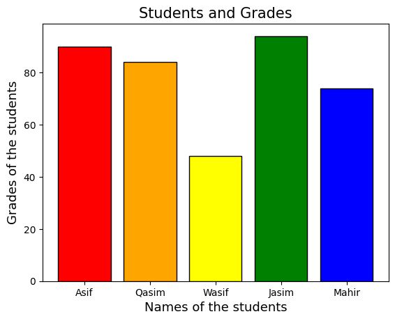

```python
grades=[90,84,48,94,74]
Names=["Asif","Qasim","Wasif","Jasim","Mahir"]
colors=["red","orange","yellow","green","blue"]
plt.bar(Names,grades,color=colors,edgecolor="black")
plt.xlabel("Names of the students",fontsize=13)
plt.ylabel("Grades of the students",fontsize=13)
plt.title("Students and Grades",fontsize=15)
plt.show
```

```python
file=pd.read_excel("ESD.xlsx")
data=pd.DataFrame(file)
data
```

|  | EEID | Full Name | Job Title | Department | Business Unit | Gender | Ethnicity | Age | Hire Date | Annual Salary | Bonus % | Country | City | Exit Date |
| --- | --- | --- | --- | --- | --- | --- | --- | --- | --- | --- | --- | --- | --- | --- |
| 0 | E02387 | Emily Davis | Sr. Manger | IT | Research & Development | Female | Black | 55 | 2016-04-08 | 141604 | 0.15 | United States | Seattle | 2021-10-16 |
| 1 | E04105 | Theodore Dinh | Technical Architect | IT | Manufacturing | Male | Asian | 59 | 1997-11-29 | 99975 | 0.00 | China | Chongqing | NaT |
| 2 | E02572 | Luna Sanders | Director | Finance | Speciality Products | Female | Caucasian | 50 | 2006-10-26 | 163099 | 0.20 | United States | Chicago | NaT |
| 3 | E02832 | Penelope Jordan | Computer Systems Manager | IT | Manufacturing | Female | Caucasian | 26 | 2019-09-27 | 84913 | 0.07 | United States | Chicago | NaT |
| 4 | E01639 | Austin Vo | Sr. Analyst | Finance | Manufacturing | Male | Asian | 55 | 1995-11-20 | 95409 | 0.00 | United States | Phoenix | NaT |
| ... | ... | ... | ... | ... | ... | ... | ... | ... | ... | ... | ... | ... | ... | ... |
| 995 | E03094 | Wesley Young | Sr. Analyst | Marketing | Speciality Products | Male | Caucasian | 33 | 2016-09-18 | 98427 | 0.00 | United States | Columbus | NaT |
| 996 | E01909 | Lillian Khan | Analyst | Finance | Speciality Products | Female | Asian | 44 | 2010-05-31 | 47387 | 0.00 | China | Chengdu | 2018-01-08 |
| 997 | E04398 | Oliver Yang | Director | Marketing | Speciality Products | Male | Asian | 31 | 2019-06-10 | 176710 | 0.15 | United States | Miami | NaT |
| 998 | E02521 | Lily Nguyen | Sr. Analyst | Finance | Speciality Products | Female | Asian | 33 | 2012-01-28 | 95960 | 0.00 | China | Chengdu | NaT |
| 999 | E03545 | Sofia Cheng | Vice President | Accounting | Corporate | Female | Asian | 63 | 2020-07-26 | 216195 | 0.31 | United States | Miami | NaT |

1000 rows × 14 columns

```
Department
Accounting         123146.947917
Engineering        109035.208861
Finance            122802.891667
Human Resources    118058.440000
IT                  97790.452282
Marketing          129663.033333
Sales              111049.857143
Name: Annual Salary, dtype: float64
```

```
<function matplotlib.pyplot.show(close=None, block=None)>
```

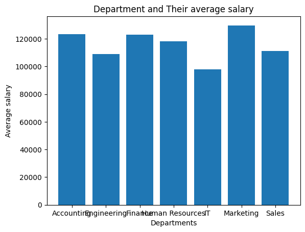

```python
groupedby=data.groupby("Department")["Annual Salary"].mean()
print(groupedby)
plt.xlabel("Departments")
plt.ylabel("Average salary")
plt.title("Department and Their average salary")
plt.bar(groupedby.index, groupedby.values)
plt.show
```

```python
data
```

|  | EEID | Full Name | Job Title | Department | Business Unit | Gender | Ethnicity | Age | Hire Date | Annual Salary | Bonus % | Country | City | Exit Date |
| --- | --- | --- | --- | --- | --- | --- | --- | --- | --- | --- | --- | --- | --- | --- |
| 0 | E02387 | Emily Davis | Sr. Manger | IT | Research & Development | Female | Black | 55 | 2016-04-08 | 141604 | 0.15 | United States | Seattle | 2021-10-16 |
| 1 | E04105 | Theodore Dinh | Technical Architect | IT | Manufacturing | Male | Asian | 59 | 1997-11-29 | 99975 | 0.00 | China | Chongqing | NaT |
| 2 | E02572 | Luna Sanders | Director | Finance | Speciality Products | Female | Caucasian | 50 | 2006-10-26 | 163099 | 0.20 | United States | Chicago | NaT |
| 3 | E02832 | Penelope Jordan | Computer Systems Manager | IT | Manufacturing | Female | Caucasian | 26 | 2019-09-27 | 84913 | 0.07 | United States | Chicago | NaT |
| 4 | E01639 | Austin Vo | Sr. Analyst | Finance | Manufacturing | Male | Asian | 55 | 1995-11-20 | 95409 | 0.00 | United States | Phoenix | NaT |
| ... | ... | ... | ... | ... | ... | ... | ... | ... | ... | ... | ... | ... | ... | ... |
| 995 | E03094 | Wesley Young | Sr. Analyst | Marketing | Speciality Products | Male | Caucasian | 33 | 2016-09-18 | 98427 | 0.00 | United States | Columbus | NaT |
| 996 | E01909 | Lillian Khan | Analyst | Finance | Speciality Products | Female | Asian | 44 | 2010-05-31 | 47387 | 0.00 | China | Chengdu | 2018-01-08 |
| 997 | E04398 | Oliver Yang | Director | Marketing | Speciality Products | Male | Asian | 31 | 2019-06-10 | 176710 | 0.15 | United States | Miami | NaT |
| 998 | E02521 | Lily Nguyen | Sr. Analyst | Finance | Speciality Products | Female | Asian | 33 | 2012-01-28 | 95960 | 0.00 | China | Chengdu | NaT |
| 999 | E03545 | Sofia Cheng | Vice President | Accounting | Corporate | Female | Asian | 63 | 2020-07-26 | 216195 | 0.31 | United States | Miami | NaT |

1000 rows × 14 columns

# line Plot

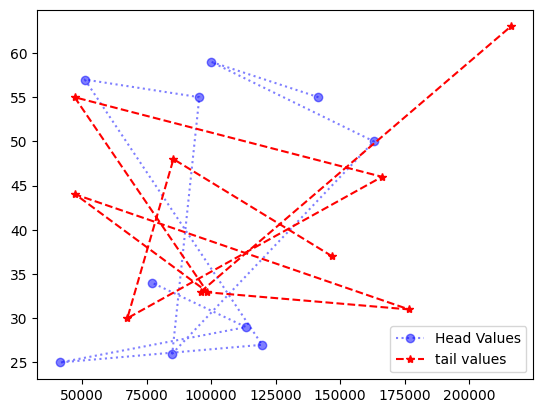

```python
plt.plot(data.head(10)["Annual Salary"],data.head(10)["Age"],linestyle='dotted', marker='o', color='b',label="Head Values",alpha=0.5)
plt.plot(data.tail(10)["Annual Salary"],data.tail(10)["Age"],ls="--",marker="*",color="r",label="tail values")
plt.legend(loc="lower right")
plt.show()
```

# Scatter plot

```
Age
25    114982.136364
26    105429.000000
27    127815.653846
28    106727.896552
29    116907.259259
30    106481.965517
31    123664.846154
32    117501.150000
33    107136.730769
34     97422.913043
35    109337.055556
36    123756.900000
37    117375.678571
38    126606.777778
```

[output cut: 28 more lines]

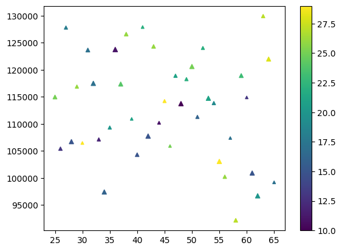

```python
grp=data.groupby(["Age"])["Annual Salary"].mean()
print(grp)
cl=np.random.randint(10,30,41)
size=np.random.randint(10,30,41)
plt.scatter(grp.index,grp.values,marker="^",c=cl,cmap='viridis',s=size)
plt.colorbar()
plt.show()
```

# Pie Chart

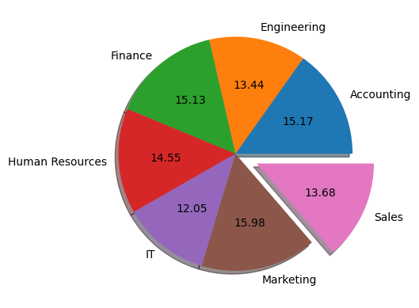

```python
ex=[0,0,0,0,0,0,0.2]
plt.pie(groupedby.values,labels=groupedby.index,explode=ex,shadow=True,autopct="%.2f")
plt.show()
```

# Box Plot

### Explanation of Quartiles, Interquartile Range, and Fences

#### 1. Quartiles

Quartiles are values that divide a dataset into four equal parts. There are three main quartiles:

- **Quartile 1 (Q1)**: The first quartile, or the 25th percentile. It separates the lowest 25% of the data from the highest 75%.
- **Quartile 2 (Q2)**: The second quartile, also known as the median or the 50th percentile. It separates the dataset into two equal halves.
- **Quartile 3 (Q3)**: The third quartile, or the 75th percentile. It separates the lowest 75% of the data from the highest 25%.

#### 2. Interquartile Range (IQR)

The Interquartile Range (IQR) is a measure of statistical dispersion and is the range between the first quartile (Q1) and the third quartile (Q3).

[ \text{IQR} = Q3 - Q1 ]

#### 3. Fences

Fences are used to identify potential outliers in the dataset. There are two types of fences:

- **Lower Fence**: The boundary below which data points are considered outliers.
- **Upper Fence**: The boundary above which data points are considered outliers.

The formulas for calculating the fences are:

[ \text{Lower Fence} = Q1 - 1.5 \times \text{IQR} ] [ \text{Upper Fence} = Q3 + 1.5 \times \text{IQR} ]

### Example Dataset

Consider the dataset: [7, 15, 36, 39, 40, 41, 42, 43, 47, 49]

### Conclusion

- **Quartiles** help to understand the spread and center of the data.
- **IQR** provides a measure of variability and identifies the range within which the central 50% of the data lies.
- **Fences** are used to detect outliers, providing insight into the potential extreme values in the dataset.

Yes, you can use a formula-based approach to find the first quartile (Q1). This method involves determining the position of the quartile in the sorted dataset. Here’s how you can do it:

### Quartile Calculation Using Formula

For a dataset with ( n ) observations, the position of the first quartile ( Q1 ) can be calculated using:

[ Q1\text{ position} = \frac{25}{100} \times (n + 1) ]

#### Steps to Calculate Q1 Using Formula

1. **Order the Data**: Arrange the data in ascending order.
2. **Calculate Q1 Position**: Use the formula ( Q1\text{ position} = \frac{25}{100} \times (n + 1) ).
3. **Interpolate if Necessary**: If the position is not an integer, interpolate between the two closest data points.

### Example

Consider the same dataset: [7, 15, 36, 39, 40, 41, 42, 43, 47, 49]

1. **Order the Data**: [ 7, 15, 36, 39, 40, 41, 42, 43, 47, 49 ] (The data is already ordered)
2. **Calculate Q1 Position**:
   - Number of observations (( n )) = 10
   - Q1 position = ( \frac{25}{100} \times (10 + 1) = \frac{25}{100} \times 11 = 2.75 )
3. **Determine Q1**:
   - The 2.75th position lies between the 2nd and 3rd data points (15 and 36).
   - Interpolate between 15 and 36: [ Q1 = 15 + 0.75 \times (36 - 15) = 15 + 0.75 \times 21 = 15 + 15.75 = 30.75 ]

### Using the Formula for All Quartiles

Similarly, you can calculate the second (Q2) and third quartiles (Q3) using their respective positions:

- **Q2 Position**: [ Q2\text{ position} = \frac{50}{100} \times (n + 1) = \frac{50}{100} \times 11 = 5.5 ]
  - This lies between the 5th and 6th data points (40 and 41).
  - Interpolate: ( Q2 = 40 + 0.5 \times (41 - 40) = 40.5 )
- **Q3 Position**: [ Q3\text{ position} = \frac{75}{100} \times (n + 1) = \frac{75}{100} \times 11 = 8.25 ]
  - This lies between the 8th and 9th data points (43 and 47).
  - Interpolate: ( Q3 = 43 + 0.25 \times (47 - 43) = 43 + 1 = 44 )

### Summary of Results Using Formula

- **Q1 (First Quartile)**: 30.75
- **Q2 (Median)**: 40.5
- **Q3 (Third Quartile)**: 44

### Conclusion

Using the formula-based approach to calculate quartiles is a systematic way to find the position and value of quartiles. This method is especially useful for larger datasets where manually finding quartiles could be cumbersome.

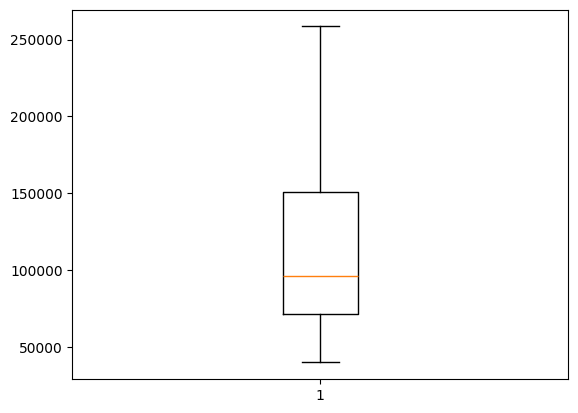

```python
plt.boxplot(data["Annual Salary"])
plt.show()
```

# Histogram and subplot

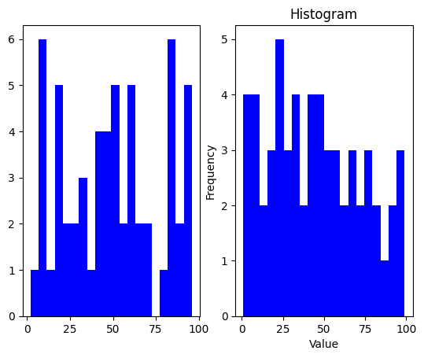

```python
# histogram is used to show the frequency of the values or data
data2 = np.random.randint(1,100,59)
plt.subplot(1,2,1)
plt.hist(data2, bins=20, color='blue')
#subplot can be used with all the charts. take parameters as (rows,columns,number of chart i.e., first second)
data2 = np.random.randint(1,100,59)
plt.subplot(1,2,2)
plt.hist(data2, bins=20, color='blue')

plt.title("Histogram")
plt.xlabel("Value")
plt.ylabel("Frequency")
plt.show()
```

## Heatmap

```
[[0.09432674 0.61500945 0.17678296 0.45564997 0.26940836 0.07279272
  0.06596492 0.87490294 0.25342999 0.5427419 ]
 [0.34528629 0.09959487 0.19655459 0.06176751 0.0460778  0.18953809
  0.20419045 0.00780717 0.95205323 0.77989042]
 [0.73934281 0.97535125 0.12682523 0.97132674 0.59756233 0.84979711
  0.98280071 0.290197   0.36334571 0.50572076]
 [0.35982622 0.19570133 0.70985654 0.54475994 0.92383932 0.53440728
  0.75339883 0.64905453 0.95612605 0.55548159]
 [0.18164498 0.00757175 0.9671481  0.07089833 0.84900394 0.50284229
  0.46250526 0.51399979 0.39091166 0.02791631]
 [0.78986724 0.07576698 0.93432747 0.05885401 0.92428617 0.14735274
  0.54790743 0.74997829 0.49683028 0.84273868]
 [0.81274962 0.12259532 0.19418054 0.25118933 0.17384365 0.68751599
  0.76563278 0.364974   0.82682065 0.35803387]
 [0.1499316  0.93874503 0.68906654 0.06169919 0.62021702 0.29408593
  0.29707849 0.76429344 0.91243331 0.68485687]
 [0.07066384 0.89891904 0.5158312  0.62795099 0.24451922 0.34772826
  0.67422578 0.8174563  0.55538112 0.87471672]
 [0.26251391 0.05714612 0.30773903 0.96774878 0.63035016 0.95860942
  0.70032987 0.74736022 0.09816829 0.38753283]]
```

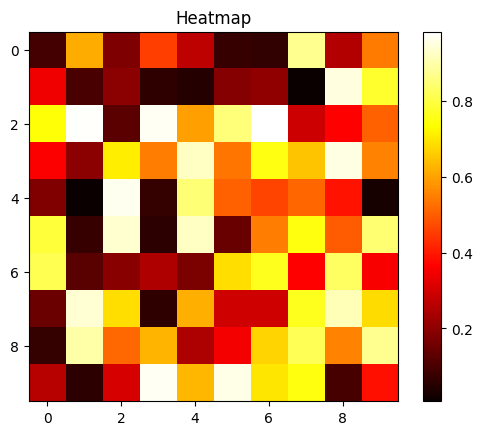

```python
data1 = np.random.rand(10, 10)
print(data1)
plt.imshow(data1, cmap='hot', interpolation='nearest')
plt.title("Heatmap")
plt.colorbar()
plt.savefig("Heatmap.png")
plt.show()
```

## voilin plot

```
0      55
1      59
2      50
3      26
4      55
       ..
995    33
996    44
997    31
998    33
999    63
Name: Age, Length: 1000, dtype: int64
```

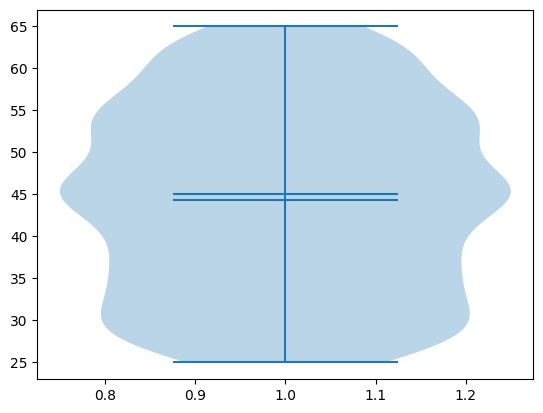

```python
print(data["Age"])
plt.violinplot(data["Age"],showmedians=True,showmeans=True)
plt.show()
```

## Stem plot

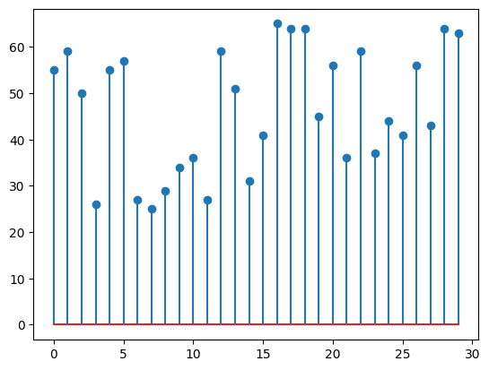

```python
plt.stem(data.head(30)["Age"])
# plt.plot(data.head(30)["Age"])
plt.show()
```

# Step chart

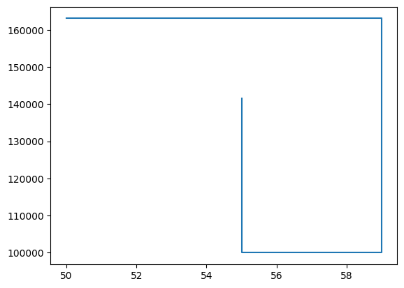

```python
plt.step(data.head(3)["Age"],data.head(3)["Annual Salary"])
plt.show()
```

### Stack Plot

A stack plot, also known as a stacked area plot, is used to display data that is accumulated over time. Each data series is represented by an area under the curve, and the areas are stacked on top of one another. This type of plot is useful for visualizing the cumulative effect of multiple data series.

### When to Use a Stack Plot

- **Cumulative Data**: When you want to show how individual parts contribute to the total over time.
- **Comparative Analysis**: When comparing multiple data series to see their individual and collective trends.

### Creating a Stack Plot with Matplotlib

Here’s how to create a stack plot using Matplotlib in Python:

#### Step-by-Step Example

Consider an example where we have data for three different categories over a period of time.

1. **Import Libraries**:

   ```
   import matplotlib.pyplot as plt
   import numpy as np
   ```

2. **Prepare Data**:

   ```
   # Time period
   days = np.arange(1, 11)

   # Data for three categories
   category1 = [5, 6, 7, 8, 9, 10, 11, 12, 13, 14]
   category2 = [3, 4, 2, 4, 6, 4, 5, 6, 7, 8]
   category3 = [2, 3, 4, 5, 6, 5, 4, 5, 6, 7]
   ```

3. **Create Stack Plot**:

   ```
   plt.stackplot(days, category1, category2, category3, labels=['Category 1', 'Category 2', 'Category 3'], colors=['#FF6347', '#4682B4', '#90EE90'])
   plt.title('Stack Plot Example')
   plt.xlabel('Days')
   plt.ylabel('Values')
   plt.legend(loc='upper left')
   plt.show()
   ```

### Detailed Explanation

- **Import Libraries**: Import the necessary libraries, including `matplotlib.pyplot` for plotting and `numpy` for handling arrays.
- **Prepare Data**: Define the time period (e.g., days) and the data for each category. Each category should have the same length as the time period.
- **Create Stack Plot**:
  - Use `plt.stackplot` to create the stack plot. Pass the time period and the data for each category as arguments.
  - `labels`: Provide labels for each category.
  - `colors`: Customize the colors of the areas.
  - `plt.title`, `plt.xlabel`, `plt.ylabel`: Add a title and labels for the x and y axes.
  - `plt.legend`: Add a legend to the plot.

### Properties of Stack Plot

- **Colors**: Customize the colors of the stacked areas using the `colors` parameter.
- **Labels**: Add labels for each stacked area using the `labels` parameter.
- **Alpha**: Adjust the transparency of the areas using the `alpha` parameter.
- **Baseline**: Change the baseline using the `baseline` parameter (options include 'zero', 'sym', 'wiggle', 'weighted_wiggle').

### Advanced Customization

Here are some additional customization options for stack plots:

#### Adding Transparency

```
plt.stackplot(days, category1, category2, category3, labels=['Category 1', 'Category 2', 'Category 3'], colors=['#FF6347', '#4682B4', '#90EE90'], alpha=0.7)
```

#### Changing Baseline

```
plt.stackplot(days, category1, category2, category3, labels=['Category 1', 'Category 2', 'Category 3'], baseline='wiggle')
```

### Complete Example

Here’s a complete example with additional customizations:

```
import matplotlib.pyplot as plt
import numpy as np

# Time period
days = np.arange(1, 11)

# Data for three categories
category1 = [5, 6, 7, 8, 9, 10, 11, 12, 13, 14]
category2 = [3, 4, 2, 4, 6, 4, 5, 6, 7, 8]
category3 = [2, 3, 4, 5, 6, 5, 4, 5, 6, 7]

# Create stack plot
plt.figure(figsize=(10, 6))
plt.stackplot(days, category1, category2, category3, labels=['Category 1', 'Category 2', 'Category 3'], colors=['#FF6347', '#4682B4', '#90EE90'], alpha=0.7)
plt.title('Stack Plot Example')
plt.xlabel('Days')
plt.ylabel('Values')
plt.legend(loc='upper left')
plt.grid(True)
plt.show()
```

### Conclusion

Stack plots are a powerful way to visualize cumulative data over time, allowing for clear comparison of multiple data series and their contributions to the whole. With Matplotlib, you can create and customize stack plots to effectively communicate your data.

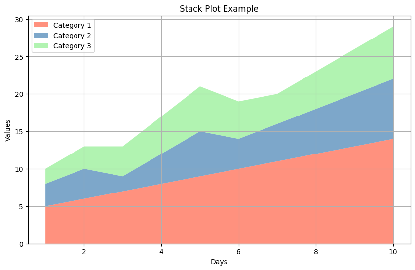

```python
days = np.arange(1, 11)

# Data for three categories
category1 = [5, 6, 7, 8, 9, 10, 11, 12, 13, 14]
category2 = [3, 4, 2, 4, 6, 4, 5, 6, 7, 8]
category3 = [2, 3, 4, 5, 6, 5, 4, 5, 6, 7]

# Create stack plot
plt.figure(figsize=(10, 6))
plt.stackplot(days, category1, category2, category3, labels=['Category 1', 'Category 2', 'Category 3'], colors=['#FF6347', '#4682B4', '#90EE90'], alpha=0.7)
plt.title('Stack Plot Example')
plt.xlabel('Days')
plt.ylabel('Values')
plt.legend(loc='upper left')
plt.grid(True)
plt.show()
```

### 3D Plotting with Matplotlib's `mplot3d` and `Axes3D`

Matplotlib’s `mplot3d` toolkit adds simple 3D plotting capabilities to your plots. The `Axes3D` class is used to create a 3D axes in a Matplotlib figure.

### Setting Up 3D Plotting

To create 3D plots, you need to import the `mpl_toolkits.mplot3d` module.

```
import matplotlib.pyplot as plt
from mpl_toolkits.mplot3d import Axes3D
import numpy as np
```

### Creating a Basic 3D Plot

Here’s a step-by-step example to create a basic 3D scatter plot:

#### Example: 3D Scatter Plot

1. **Import Libraries**:

   ```
   import matplotlib.pyplot as plt
   from mpl_toolkits.mplot3d import Axes3D
   import numpy as np
   ```

2. **Generate Data**:

   ```
   # Generate random data
   np.random.seed(42)
   x = np.random.standard_normal(100)
   y = np.random.standard_normal(100)
   z = np.random.standard_normal(100)
   ```

3. **Create 3D Axes and Plot**:

   ```
   fig = plt.figure()
   ax = fig.add_subplot(111, projection='3d')

   # Create scatter plot
   ax.scatter(x, y, z, c='r', marker='o')

   ax.set_title('3D Scatter Plot')
   ax.set_xlabel('X Axis')
   ax.set_ylabel('Y Axis')
   ax.set_zlabel('Z Axis')

   plt.show()
   ```

### Common 3D Plot Types

1. **3D Line Plot**:

   ```
   fig = plt.figure()
   ax = fig.add_subplot(111, projection='3d')

   # Generate data
   t = np.linspace(0, 2*np.pi, 100)
   x = np.sin(t)
   y = np.cos(t)
   z = t

   # Create line plot
   ax.plot(x, y, z)

   ax.set_title('3D Line Plot')
   ax.set_xlabel('X Axis')
   ax.set_ylabel('Y Axis')
   ax.set_zlabel('Z Axis')

   plt.show()
   ```

2. **3D Surface Plot**:

   ```
   fig = plt.figure()
   ax = fig.add_subplot(111, projection='3d')

   # Generate data
   x = np.linspace(-5, 5, 100)
   y = np.linspace(-5, 5, 100)
   x, y = np.meshgrid(x, y)
   z = np.sin(np.sqrt(x**2 + y**2))

   # Create surface plot
   ax.plot_surface(x, y, z, cmap='viridis')

   ax.set_title('3D Surface Plot')
   ax.set_xlabel('X Axis')
   ax.set_ylabel('Y Axis')
   ax.set_zlabel('Z Axis')

   plt.show()
   ```

3. **3D Wireframe Plot**:

   ```
   fig = plt.figure()
   ax = fig.add_subplot(111, projection='3d')

   # Generate data
   x = np.linspace(-5, 5, 100)
   y = np.linspace(-5, 5, 100)
   x, y = np.meshgrid(x, y)
   z = np.sin(np.sqrt(x**2 + y**2))

   # Create wireframe plot
   ax.plot_wireframe(x, y, z)

   ax.set_title('3D Wireframe Plot')
   ax.set_xlabel('X Axis')
   ax.set_ylabel('Y Axis')
   ax.set_zlabel('Z Axis')

   plt.show()
   ```

4. **3D Bar Plot**:

   ```
   fig = plt.figure()
   ax = fig.add_subplot(111, projection='3d')

   # Generate data
   _x = np.arange(4)
   _y = np.arange(3)
   _xx, _yy = np.meshgrid(_x, _y)
   x, y = _xx.ravel(), _yy.ravel()

   top = x + y
   bottom = np.zeros_like(top)
   width = depth = 1

   # Create bar plot
   ax.bar3d(x, y, bottom, width, depth, top, shade=True)

   ax.set_title('3D Bar Plot')
   ax.set_xlabel('X Axis')
   ax.set_ylabel('Y Axis')
   ax.set_zlabel('Z Axis')

   plt.show()
   ```

### Customizing 3D Plots

You can customize various aspects of 3D plots, such as:

- **Colors**: Use the `cmap` parameter for color maps.
- **Labels**: Set labels for axes using `set_xlabel`, `set_ylabel`, and `set_zlabel`.
- **Titles**: Set the title of the plot using `set_title`.
- **Markers**: Customize markers in scatter plots using the `marker` parameter.
- **Shading**: Adjust shading in surface plots using the `shade` parameter.

### Example with Customizations

```
fig = plt.figure()
ax = fig.add_subplot(111, projection='3d')

# Generate data
x = np.linspace(-5, 5, 100)
y = np.linspace(-5, 5, 100)
x, y = np.meshgrid(x, y)
z = np.sin(np.sqrt(x**2 + y**2))

# Create surface plot with customizations
surface = ax.plot_surface(x, y, z, cmap='coolwarm', edgecolor='none')

ax.set_title('Customized 3D Surface Plot')
ax.set_xlabel('X Axis')
ax.set_ylabel('Y Axis')
ax.set_zlabel('Z Axis')

# Add color bar
fig.colorbar(surface, ax=ax, shrink=0.5, aspect=5)

plt.show()
```

### Conclusion

Using Matplotlib’s `mplot3d` toolkit and `Axes3D`, you can create various types of 3D plots to visualize data in three dimensions. Customizing these plots allows you to create informative and visually appealing visualizations.

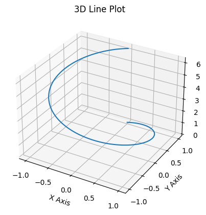

```python
fig = plt.figure()
ax = fig.add_subplot(111, projection='3d')

# Generate data
t = np.linspace(0, 2*np.pi, 100)
x = np.sin(t)
y = np.cos(t)
z = t

# Create line plot
ax.plot(x, y, z)

ax.set_title('3D Line Plot')
ax.set_xlabel('X Axis')
ax.set_ylabel('Y Axis')
ax.set_zlabel('Z Axis')
```

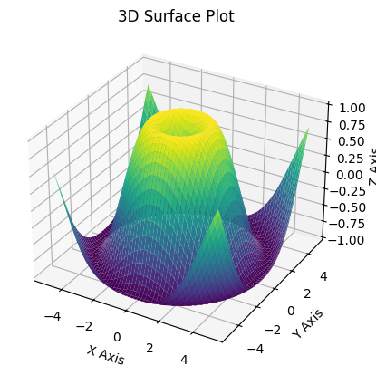

```python
fig = plt.figure()
ax = fig.add_subplot(111, projection='3d')

# Generate data
x = np.linspace(-5, 5, 100)
y = np.linspace(-5, 5, 100)
x, y = np.meshgrid(x, y)
z = np.sin(np.sqrt(x**2 + y**2))

# Create surface plot
ax.plot_surface(x, y, z, cmap='viridis')

ax.set_title('3D Surface Plot')
ax.set_xlabel('X Axis')
ax.set_ylabel('Y Axis')
ax.set_zlabel('Z Axis')
```

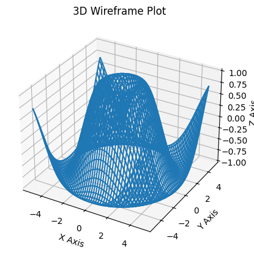

```python
fig = plt.figure()
ax = fig.add_subplot(111, projection='3d')

# Generate data
x = np.linspace(-5, 5, 100)
y = np.linspace(-5, 5, 100)
x, y = np.meshgrid(x, y)
z = np.sin(np.sqrt(x**2 + y**2))

# Create wireframe plot
ax.plot_wireframe(x, y, z)

ax.set_title('3D Wireframe Plot')
ax.set_xlabel('X Axis')
ax.set_ylabel('Y Axis')
ax.set_zlabel('Z Axis')
```

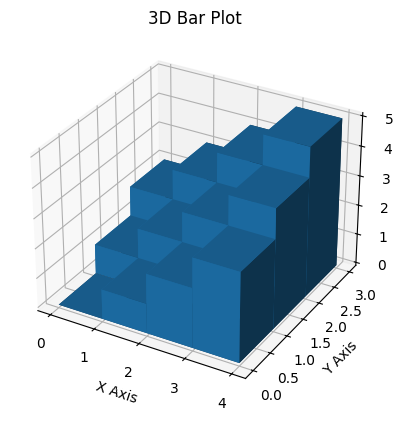

```python
fig = plt.figure()
ax = fig.add_subplot(111, projection='3d')

# Generate data
_x = np.arange(4)
_y = np.arange(3)
_xx, _yy = np.meshgrid(_x, _y)
x, y = _xx.ravel(), _yy.ravel()

top = x + y
bottom = np.zeros_like(top)
width = depth = 1

# Create bar plot
ax.bar3d(x, y, bottom, width, depth, top, shade=True)

ax.set_title('3D Bar Plot')
ax.set_xlabel('X Axis')
ax.set_ylabel('Y Axis')
ax.set_zlabel('Z Axis')
```

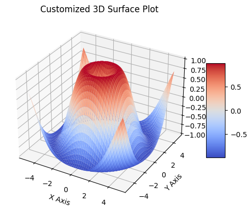

```python
fig = plt.figure()
ax = fig.add_subplot(111, projection='3d')

# Generate data
x = np.linspace(-5, 5, 100)
y = np.linspace(-5, 5, 100)
x, y = np.meshgrid(x, y)
z = np.sin(np.sqrt(x**2 + y**2))

# Create surface plot with customizations
surface = ax.plot_surface(x, y, z, cmap='coolwarm', edgecolor='none')

ax.set_title('Customized 3D Surface Plot')
ax.set_xlabel('X Axis')
ax.set_ylabel('Y Axis')
ax.set_zlabel('Z Axis')

# Add color bar
fig.colorbar(surface, ax=ax, shrink=0.5, aspect=5)

plt.show()
```